# Modeling and prediction for movies

## Setup

### Load packages

```r
library(ggplot2)
library(dplyr)
library(statsr)
```

### Load data

Make sure your data and R Markdown files are in the same directory. When loaded your data file will be called `movies`. Delete this note when before you submit your work.

```r
load("movies.Rdata")
```

```r
summary(movies)
```

```
##     title                  title_type                 genre        runtime
##  Length:651         Documentary : 55   Drama             :305   Min.   : 39.0
##  Class :character   Feature Film:591   Comedy            : 87   1st Qu.: 92.0
##  Mode  :character   TV Movie    :  5   Action & Adventure: 65   Median :103.0
##                                        Mystery & Suspense: 59   Mean   :105.8
##                                        Documentary       : 52   3rd Qu.:115.8
##                                        Horror            : 23   Max.   :267.0
##                                        (Other)           : 60   NA's   :1
##   mpaa_rating                               studio    thtr_rel_year
##  G      : 19   Paramount Pictures              : 37   Min.   :1970
##  NC-17  :  2   Warner Bros. Pictures           : 30   1st Qu.:1990
##  PG     :118   Sony Pictures Home Entertainment: 27   Median :2000
##  PG-13  :133   Universal Pictures              : 23   Mean   :1998
##  R      :329   Warner Home Video               : 19   3rd Qu.:2007
##  Unrated: 50   (Other)                         :507   Max.   :2014
##                NA's                            :  8
##  thtr_rel_month   thtr_rel_day    dvd_rel_year  dvd_rel_month
##  Min.   : 1.00   Min.   : 1.00   Min.   :1991   Min.   : 1.000
##  1st Qu.: 4.00   1st Qu.: 7.00   1st Qu.:2001   1st Qu.: 3.000
##  Median : 7.00   Median :15.00   Median :2004   Median : 6.000
##  Mean   : 6.74   Mean   :14.42   Mean   :2004   Mean   : 6.333
##  3rd Qu.:10.00   3rd Qu.:21.00   3rd Qu.:2008   3rd Qu.: 9.000
##  Max.   :12.00   Max.   :31.00   Max.   :2015   Max.   :12.000
##                                  NA's   :8      NA's   :8
##   dvd_rel_day     imdb_rating    imdb_num_votes           critics_rating
##  Min.   : 1.00   Min.   :1.900   Min.   :   180   Certified Fresh:135
##  1st Qu.: 7.00   1st Qu.:5.900   1st Qu.:  4546   Fresh          :209
##  Median :15.00   Median :6.600   Median : 15116   Rotten         :307
##  Mean   :15.01   Mean   :6.493   Mean   : 57533
##  3rd Qu.:23.00   3rd Qu.:7.300   3rd Qu.: 58301
##  Max.   :31.00   Max.   :9.000   Max.   :893008
##  NA's   :8
##  critics_score    audience_rating audience_score  best_pic_nom best_pic_win
##  Min.   :  1.00   Spilled:275     Min.   :11.00   no :629      no :644
##  1st Qu.: 33.00   Upright:376     1st Qu.:46.00   yes: 22      yes:  7
##  Median : 61.00                   Median :65.00
##  Mean   : 57.69                   Mean   :62.36
##  3rd Qu.: 83.00                   3rd Qu.:80.00
##  Max.   :100.00                   Max.   :97.00
##
```

[output cut: 9 more lines]

```
##  Length:651         Length:651         Length:651         Length:651
##  Class :character   Class :character   Class :character   Class :character
##  Mode  :character   Mode  :character   Mode  :character   Mode  :character
##
##
##
##
##     actor5            imdb_url            rt_url
##  Length:651         Length:651         Length:651
##  Class :character   Class :character   Class :character
##  Mode  :character   Mode  :character   Mode  :character
##
##
##
##
```

## Part 1: Data

The data set is comprised of 651 randomly sampled movies produced and released before 2016.

### Generalizability of Data.

I don’t think so that the results from this sample can be generalize to the entire movies ever made before 2016.Since there are large number of movies present out there and we have very very very small sample which is not enough to generalize.Also the random sampling is done but there is nothing mention about the stratified sampling on the data so this is another reason why we won’t be able to generalize our results to all the movies.

### Causality of Data.

Since these are mere observations that were randomly collected without dividing them further into control and treatment groups so We cannot establish causal relationship. We can only derive correlational relationship.

## Part 2: Research question

My team’s main research question would be to identify what are the attributes which would make a movie great. Basically with the help of this dataset we will be going to model those attributes which would lead to the high IMDB ratings of a movie or to put it in other words we will be going to identify all those significant predictors/Attributes which are responsible for the high IMDB ratings.

Finally our main research question would answer “Is there any association between the chosen attributes and IMDB ratings or not”.

## Part 3: Exploratory data analysis

NOTE: Insert code chunks as needed by clicking on the “Insert a new code chunk” button above. Make sure that your code is visible in the project you submit. Delete this note when before you submit your work.

For this question we will be going to select the given attributes in our model.

1.title_type. 2.genre 3.runtime 4.mpaa_rating 5.thtr_rel_day 6.thtr_rel_month 7.critics_rating 8.audience_rating

Response variable. imdb_rating.

So we will be going to visualize some of these individual attributes against imdb_rating - our response variable through graphical methods and try to gain some insights from it.

1.title_type vs imdb_rating

We will be going for box plot analysis because boxplot helps to visualize with explainatory categeorical and numerical response variable.

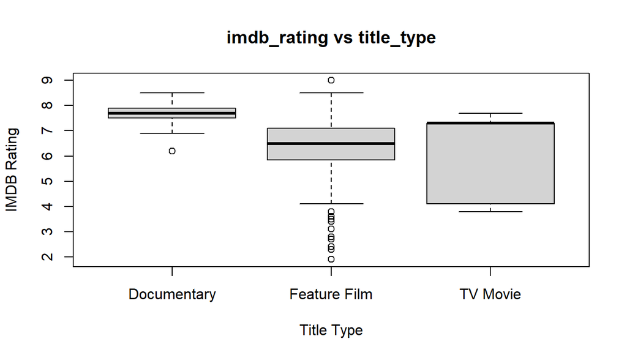

```r
boxplot(imdb_rating~title_type,
data=movies,
main="imdb_rating vs title_type",
xlab="Title Type",
ylab="IMDB Rating"
)
```

2.genre vs imdb_rating

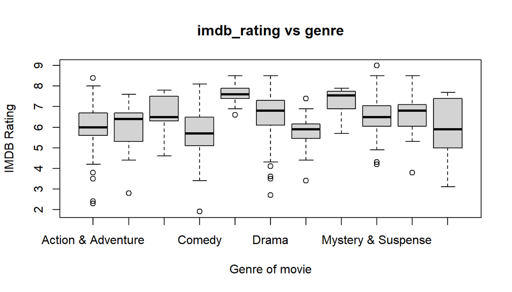

```r
boxplot(imdb_rating~genre,
data=movies,
main="imdb_rating vs genre",
xlab="Genre of movie",
ylab="IMDB Rating"
)
```

There is definetly something going on here.The genre is affecting the ratings of the movie.

3.Runtime vs Imdb ratings

we will be going to use the scatter plot for visualizing this relationship.

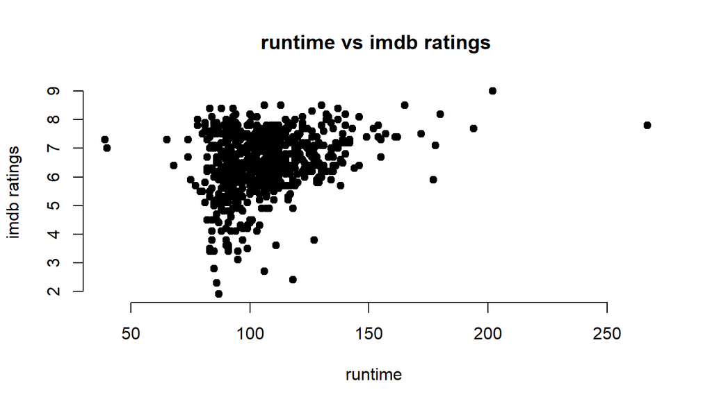

```r
plot(movies$runtime, movies$imdb_rating, main = "runtime vs imdb ratings",
     xlab = "runtime ", ylab = "imdb ratings",
     pch = 19, frame = FALSE)
```

We can see the positive correlation between the two variables.

## Part 4: Modeling

In this section we will be going to develop the multiple regression model in order to predict the imdb ratings for the future movies based on there attributes.

Following are the variables we are considering for our regression.

1.title_type. 2.genre 3.runtime 4.mpaa_rating 5.thtr_rel_day 6.thtr_rel_month 7.critics_rating 8.audience_rating

We had exclude various variables such as year of release , title of movie because such variables are not that significant for our prediction because they do not affect the overall ratings of the movie.

We will be using the multiple linear regression for carrying out our prediction and modelling the given set of data.

```r
ratings_model <- lm(imdb_rating ~ title_type + genre + runtime + mpaa_rating + thtr_rel_day + thtr_rel_month + critics_rating + audience_rating, data = movies)
summary(ratings_model)
```

```
##
## Call:
## lm(formula = imdb_rating ~ title_type + genre + runtime + mpaa_rating +
##     thtr_rel_day + thtr_rel_month + critics_rating + audience_rating,
##     data = movies)
##
## Residuals:
##      Min       1Q   Median       3Q      Max
## -3.15580 -0.30005  0.05912  0.40522  1.54253
##
## Coefficients:
##                                 Estimate Std. Error t value Pr(>|t|)
## (Intercept)                     5.860717   0.340073  17.234  < 2e-16 ***
## title_typeFeature Film         -0.225488   0.244300  -0.923  0.35636
## title_typeTV Movie             -0.651305   0.384585  -1.694  0.09085 .
## genreAnimation                 -0.574083   0.256695  -2.236  0.02567 *
## genreArt House & International  0.207568   0.199631   1.040  0.29885
## genreComedy                    -0.125059   0.109425  -1.143  0.25353
## genreDocumentary                0.533509   0.261700   2.039  0.04191 *
## genreDrama                      0.184589   0.094493   1.953  0.05121 .
## genreHorror                     0.082930   0.164303   0.505  0.61392
## genreMusical & Performing Arts  0.338982   0.223890   1.514  0.13052
## genreMystery & Suspense         0.299808   0.122471   2.448  0.01464 *
## genreOther                      0.075189   0.187059   0.402  0.68786
## genreScience Fiction & Fantasy -0.362317   0.234747  -1.543  0.12323
## runtime                         0.008620   0.001494   5.769 1.25e-08 ***
## mpaa_ratingNC-17               -0.373708   0.497908  -0.751  0.45320
## mpaa_ratingPG                  -0.354691   0.180702  -1.963  0.05011 .
## mpaa_ratingPG-13               -0.420991   0.185647  -2.268  0.02369 *
## mpaa_ratingR                   -0.334371   0.178986  -1.868  0.06221 .
## mpaa_ratingUnrated             -0.388746   0.206190  -1.885  0.05984 .
## thtr_rel_day                   -0.001308   0.003009  -0.435  0.66406
## thtr_rel_month                  0.005818   0.007578   0.768  0.44293
## critics_ratingFresh            -0.208945   0.075657  -2.762  0.00592 **
## critics_ratingRotten           -0.791983   0.080681  -9.816  < 2e-16 ***
## audience_ratingUpright          0.967146   0.064715  14.945  < 2e-16 ***
## ---
## Signif. codes:  0 '***' 0.001 '**' 0.01 '*' 0.05 '.' 0.1 ' ' 1
##
## Residual standard error: 0.6561 on 626 degrees of freedom
##   (1 observation deleted due to missingness)
## Multiple R-squared:  0.6472, Adjusted R-squared:  0.6342
## F-statistic: 49.93 on 23 and 626 DF,  p-value: < 2.2e-16
```

With the above model we will observe that the theater release day and month are not at all significant predictors therefore we will remove them from our model and now see the result.

Dropping thtr_rel_day and thtr_rel_month

```r
ratings_model <- lm(imdb_rating ~ title_type + genre + runtime + mpaa_rating + critics_rating + audience_rating, data = movies)
summary(ratings_model)
```

```
##
## Call:
## lm(formula = imdb_rating ~ title_type + genre + runtime + mpaa_rating +
##     critics_rating + audience_rating, data = movies)
##
## Residuals:
##     Min      1Q  Median      3Q     Max
## -3.1627 -0.3036  0.0595  0.4109  1.5564
##
## Coefficients:
##                                 Estimate Std. Error t value Pr(>|t|)
## (Intercept)                     5.854937   0.336475  17.401  < 2e-16 ***
## title_typeFeature Film         -0.226213   0.244043  -0.927  0.35431
## title_typeTV Movie             -0.663935   0.383888  -1.730  0.08421 .
## genreAnimation                 -0.567840   0.256260  -2.216  0.02706 *
## genreArt House & International  0.199967   0.198619   1.007  0.31443
## genreComedy                    -0.120175   0.109158  -1.101  0.27135
## genreDocumentary                0.532204   0.261412   2.036  0.04218 *
## genreDrama                      0.182990   0.094354   1.939  0.05290 .
## genreHorror                     0.080815   0.163982   0.493  0.62231
## genreMusical & Performing Arts  0.339198   0.223608   1.517  0.12979
## genreMystery & Suspense         0.293617   0.122115   2.404  0.01649 *
## genreOther                      0.073277   0.186534   0.393  0.69457
## genreScience Fiction & Fantasy -0.358279   0.234185  -1.530  0.12655
## runtime                         0.008888   0.001451   6.125  1.6e-09 ***
## mpaa_ratingNC-17               -0.380345   0.497253  -0.765  0.44462
## mpaa_ratingPG                  -0.355155   0.180449  -1.968  0.04949 *
## mpaa_ratingPG-13               -0.428688   0.185144  -2.315  0.02091 *
## mpaa_ratingR                   -0.334050   0.178797  -1.868  0.06218 .
## mpaa_ratingUnrated             -0.390098   0.205922  -1.894  0.05863 .
## critics_ratingFresh            -0.206922   0.074840  -2.765  0.00586 **
## critics_ratingRotten           -0.790445   0.080287  -9.845  < 2e-16 ***
## audience_ratingUpright          0.966617   0.064646  14.953  < 2e-16 ***
## ---
## Signif. codes:  0 '***' 0.001 '**' 0.01 '*' 0.05 '.' 0.1 ' ' 1
##
## Residual standard error: 0.6554 on 628 degrees of freedom
##   (1 observation deleted due to missingness)
## Multiple R-squared:  0.6468, Adjusted R-squared:  0.635
## F-statistic: 54.76 on 21 and 628 DF,  p-value: < 2.2e-16
```

our Adjusted R squared did improved but very very minutely.

## Part 5: Prediction

Below is the prediction shown.We will first create the data frame containing the values/attributes of a movie and based upon those attributes our model will be predicting the potential rating of a movie.

```r
newmovie <- data.frame(title_type = "Documentary", genre = "Documentary", runtime = 120, mpaa_rating = "R", critics_rating = "Fresh", audience_rating = "Spilled")
```

Getting predictions of ratings on this new movie.

```r
predict(ratings_model, newmovie)
```

```
##        1
## 6.912709
```

We got our prediction as 6.9 ~ 7 star ratings.

We can also construct a prediction interval around this prediction, which will provide a measure of uncertainty around the prediction.

```r
predict(ratings_model, newmovie, interval = "prediction", level = 0.95)
```

```
##        fit      lwr      upr
## 1 6.912709 5.593403 8.232015
```

Hence, the model predicts, with 95% confidence, that a movie with these attributes as mentioned in newmovie dataframe is expected to have an ratings between 5.593403 and 8.232015.

## Part 6: Conclusion

Hence with the considered predictors we are able to explain about 65% of the variability in our dataset on the imdb ratings.

This study deals with the research question directly as we had find the significant predictors or attributes set which is responsible for making the movie popular.

One potential application of this is If we need to invest in the movies to maximize our return on investments we might look to this model to give us heads up.

#### Shortcomings.

1.We need to sample more data instead of only 651 movies sample.

2.Instead of getting all the genres of movie mixed we need to do the independent modeling of the genres of movie and then we need to find the association between ratings and other attributes.